# Solutions — Session 11: Regression Drivers of Satisfaction

M731 · Full worked walkthrough (companion to session-11.qmd)

Author

Shay Abbasi

## Purpose

Full worked version of the compressed Session 11 regression walkthrough: linear regression, diagnostics, standardised coefficients, interactions, and a logistic-regression coda reusing the Week 10 A/B dataset.

## Setup

```r
library(tidyverse)
library(broom)
library(car)
library(lmtest)
library(sandwich)
library(lm.beta)
library(emmeans)

survey <- read_csv("data/maritime_survey.csv") |>
  mutate(tier = factor(tier, levels = c("Standard", "Signature", "Discovery")))
```

## Step 1 — Fit the model

```r
fit <- lm(satisfaction ~ tenure_months + tier + region + age, data = survey)
summary(fit)
```

```
Call:
lm(formula = satisfaction ~ tenure_months + tier + region + age,
    data = survey)

Residuals:
    Min      1Q  Median      3Q     Max
-3.5404 -0.6999  0.0339  0.6988  3.2648

Coefficients:
                        Estimate Std. Error t value Pr(>|t|)
(Intercept)             5.310404   0.161962  32.788  < 2e-16 ***
tenure_months           0.013243   0.002209   5.994 3.11e-09 ***
tierSignature           0.227074   0.085857   2.645  0.00834 **
tierDiscovery           0.636070   0.104677   6.077 1.91e-09 ***
regionOntario_prospect -0.014272   0.079721  -0.179  0.85796
age                     0.002891   0.003708   0.780  0.43575
---
Signif. codes:  0 '***' 0.001 '**' 0.01 '*' 0.05 '.' 0.1 ' ' 1

Residual standard error: 1.078 on 794 degrees of freedom
Multiple R-squared:  0.0871,    Adjusted R-squared:  0.08135
F-statistic: 15.15 on 5 and 794 DF,  p-value: 3.102e-14
```

```r
tidy(fit, conf.int = TRUE)
```

```
# A tibble: 6 × 7
  term                 estimate std.error statistic   p.value conf.low conf.high
  <chr>                   <dbl>     <dbl>     <dbl>     <dbl>    <dbl>     <dbl>
1 (Intercept)           5.31      0.162      32.8   9.26e-150  4.99       5.63
2 tenure_months         0.0132    0.00221     5.99  3.11e-  9  0.00891    0.0176
3 tierSignature         0.227     0.0859      2.64  8.34e-  3  0.0585     0.396
4 tierDiscovery         0.636     0.105       6.08  1.91e-  9  0.431      0.842
5 regionOntario_prosp… -0.0143    0.0797     -0.179 8.58e-  1 -0.171      0.142
6 age                   0.00289   0.00371     0.780 4.36e-  1 -0.00439    0.0102
```

```r
glance(fit)
```

```
# A tibble: 1 × 12
  r.squared adj.r.squared sigma statistic  p.value    df logLik   AIC   BIC
      <dbl>         <dbl> <dbl>     <dbl>    <dbl> <dbl>  <dbl> <dbl> <dbl>
1    0.0871        0.0814  1.08      15.2 3.10e-14     5 -1192. 2399. 2432.
# ℹ 3 more variables: deviance <dbl>, df.residual <int>, nobs <int>
```

**Interpretation.** Read each coefficient as “holding the other predictors constant.” Tier dummies compare Signature and Discovery to the reference level (Standard); a positive, significant Discovery coefficient means Discovery subscribers report higher satisfaction than Standard subscribers, net of tenure, region, and age — consistent with the Week 7 ANOVA finding, now controlling for other factors.

## Step 2 — Diagnostics

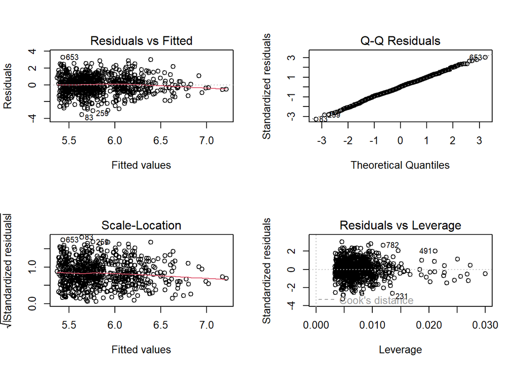

Figure 1: Regression diagnostic panel

```r
par(mfrow = c(2, 2))
plot(fit)
par(mfrow = c(1, 1))
```

```r
vif(fit)
```

```
                  GVIF Df GVIF^(1/(2*Df))
tenure_months 1.003732  1        1.001864
tier          1.005469  2        1.001364
region        1.001400  1        1.000700
age           1.007047  1        1.003517
```

```r
bptest(fit)
```

```
    studentized Breusch-Pagan test

data:  fit
BP = 9.0144, df = 5, p-value = 0.1085
```

**Interpretation.** VIFs should sit comfortably under 5 — tenure, tier, region, and age aren’t redundant with each other here. If the Breusch-Pagan test rejects (p < .05), switch to robust standard errors:

```r
coeftest(fit, vcov = vcovHC(fit, type = "HC3"))
```

```
t test of coefficients:

                         Estimate Std. Error t value  Pr(>|t|)
(Intercept)             5.3104040  0.1666603 31.8636 < 2.2e-16 ***
tenure_months           0.0132430  0.0020900  6.3363 3.941e-10 ***
tierSignature           0.2270745  0.0887462  2.5587   0.01069 *
tierDiscovery           0.6360698  0.0997263  6.3782 3.041e-10 ***
regionOntario_prospect -0.0142721  0.0803231 -0.1777   0.85902
age                     0.0028912  0.0038033  0.7602   0.44738
---
Signif. codes:  0 '***' 0.001 '**' 0.01 '*' 0.05 '.' 0.1 ' ' 1
```

## Step 3 — Standardised coefficients (driver importance)

```r
lm.beta(fit)
```

```
Call:
lm(formula = satisfaction ~ tenure_months + tier + region + age,
    data = survey)

Standardized Coefficients::
           (Intercept)          tenure_months          tierSignature
                    NA            0.203616795            0.095507491
         tierDiscovery regionOntario_prospect                    age
           0.219113594           -0.006074636            0.026533674
```

**Interpretation.** Standardised coefficients put tenure, tier, region, and age on a common (SD-unit) scale, letting you rank them by relative importance — useful for a slide that says “the three biggest drivers of satisfaction are X, Y, Z,” which raw coefficients on different scales can’t support directly.

## Step 4 — Interaction: does tenure matter differently by tier?

```r
fit_int <- lm(satisfaction ~ tenure_months * tier + region + age, data = survey)
tidy(fit_int, conf.int = TRUE)
```

```
# A tibble: 8 × 7
  term                 estimate std.error statistic   p.value conf.low conf.high
  <chr>                   <dbl>     <dbl>     <dbl>     <dbl>    <dbl>     <dbl>
1 (Intercept)           5.31      0.167      31.8   7.94e-144  4.98      5.64
2 tenure_months         0.0141    0.00318     4.44  1.05e-  5  0.00786   0.0203
3 tierSignature         0.198     0.121       1.64  1.01e-  1 -0.0387    0.435
4 tierDiscovery         0.757     0.147       5.14  3.41e-  7  0.468     1.05
5 regionOntario_prosp… -0.0101    0.0801     -0.126 9.00e-  1 -0.167     0.147
6 age                   0.00252   0.00372     0.677 4.98e-  1 -0.00478   0.00981
7 tenure_months:tierS…  0.00178   0.00510     0.350 7.26e-  1 -0.00822   0.0118
8 tenure_months:tierD… -0.00677   0.00583    -1.16  2.46e-  1 -0.0182    0.00467
```

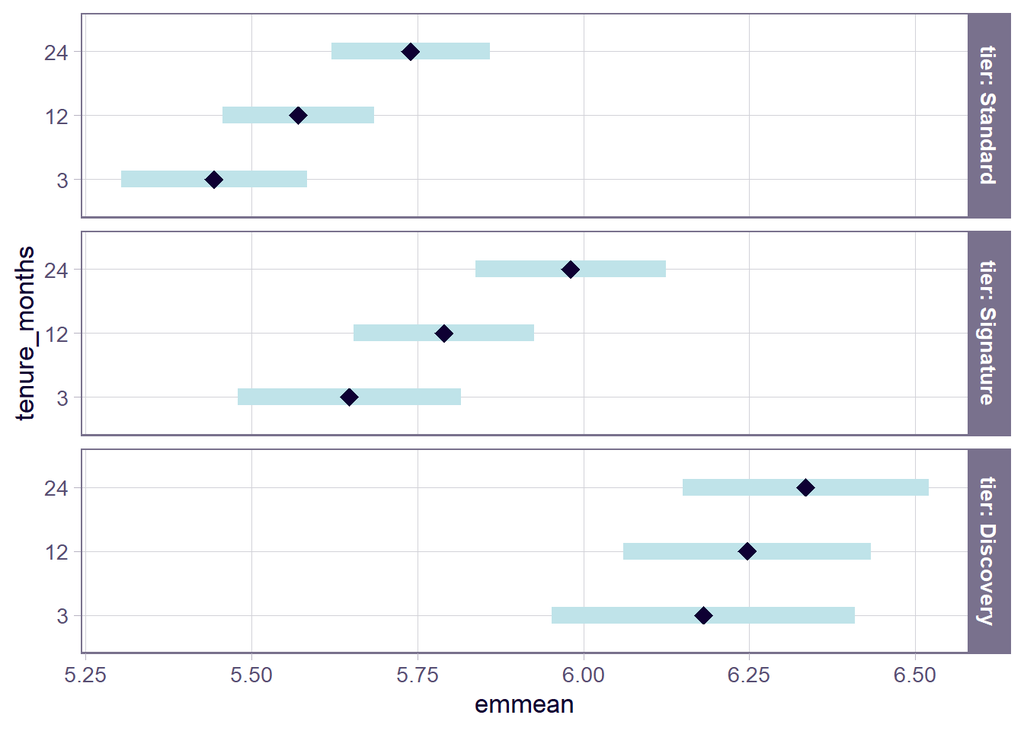

Figure 2: Estimated satisfaction by tenure and tier

```r
emm <- emmeans(fit_int, ~ tenure_months | tier, at = list(tenure_months = c(3, 12, 24)))
plot(emm)
```

**Interpretation.** If the interaction term is not significant, the tenure effect is essentially parallel across tiers — the simpler additive model (Step 1) is preferred on grounds of parsimony.

## Step 5 — Logistic regression coda (reusing the Week 10 A/B data)

```r
ab <- read_csv("data/maritime_abtest.csv")

fit_log <- glm(upgraded ~ tenure_months + treatment + age, family = binomial, data = ab)
tidy(fit_log, exponentiate = TRUE, conf.int = TRUE)
```

```
# A tibble: 4 × 7
  term               estimate std.error statistic  p.value conf.low conf.high
  <chr>                 <dbl>     <dbl>     <dbl>    <dbl>    <dbl>     <dbl>
1 (Intercept)          0.0697   0.267       -9.98 1.96e-23   0.0411     0.117
2 tenure_months        1.01     0.00308      4.67 3.02e- 6   1.01       1.02
3 treatmentnew_offer   1.69     0.130        4.04 5.34e- 5   1.31       2.19
4 age                  1.01     0.00604      1.36 1.73e- 1   0.996      1.02
```

**Interpretation.** Odds ratios above 1 increase the odds of upgrading; below 1 decrease it. Remember: an odds ratio of 2 does not mean “twice as likely” in probability terms — always convert back to predicted probabilities (e.g., with `emmeans` or `predict(type = "response")`) before putting a number in front of a non-technical audience.

## Step 6 — Interpretation for a general manager (100 words)

> Satisfaction is highest among Discovery subscribers and rises modestly with tenure, holding other factors constant; region and age show smaller effects. Standardised coefficients indicate tier membership is the single largest driver of satisfaction we can measure directly. **Practically**: investments in moving Standard subscribers toward Signature or Discovery (via bundling, trial upgrades, or targeted offers) are likely to move satisfaction more than tenure-based loyalty programs alone — though tenure still helps at the margin.

## Take-away for students

Say “associated with,” never “causes,” when reporting observational regression results — a rule this deck’s own ethics thread insists on. The A/B test in Week 10 is what actually identifies a causal effect; this regression identifies associations conditional on the observed covariates.